# Parameter sensitivity analysis

Loading R packages

```r
library(SWATplusR)
library(sensitivity)
library(fast)
library(hydroGOF)
library(dplyr)
library(forcats)
library(tidyr)
library(ggplot2)
library(lhs)
library(purrr)
library(lubridate)
```

Loading model

```r
# The path where the SWAT project is written

path_2012 <- "/home/sergio/Documents/R/github-rswat-ver/swat_models/TxtInOut"

#"C:/Veracruz/SWAT/github-rswat-ver/swat_models/sim_swat_t"

# Daily observed discharge gavilanes outlet (2015-05-02 to 2016-09-12)
q_obs <- q_obs_gav
```

# Influential pars in the hydrology of tropical areas.

Manual calibration of LAI growth: r__SOL_ALB().sol -0.3 0.3 r__BLAI{1,2,40,6,12,94}.plant.dat -0.9 0.9 r__CANMX.hru -0.4 0.4

Calibration based on observed data SD/mean: r__SOL_AWC().sol -0.35 0.35 r__SOL_K().sol -0.8 0.8 r__SOL_Z().sol -0.3 0.3 r__CN2.mgt -0.25 0.25

Arbitrary calibration: v__ALPHA_BF.gw 0 1 v__GW_DELAY.gw 0 650 v__GW_REVAP.gw 0.02 0.2 v__GWQMN.gw 0 2000 v__RCHRG_DP.gw 0 1 v__REVAPMN.gw 0 500 v__CH_K2.rte 5 130 v__CH_N2.rte 0 0.3 v__EPCO.hru 0 1 v__ESCO.hru 0 1 r__HRU_SLP.hru -0.2 0.2 r__SLSUBBSN.hru -0.3 0.3 v__SURLAG.bsn 0 10

# Type of change

r = ‘relchg’, multiply v = “absval”, replace a = “abschg”, add ‘pctchg’,

Define the parameter names in SWAT2012, these are equal to SWATCUP

```r
par_names <- c("SOL_AWC.sol|change = relchg",
               "SOL_K.sol|change = relchg",
               "SOL_Z.sol|change = relchg",
               "CN2.mgt|change = relchg",
               "ALPHA_BF.gw|change = absval",
               "GW_DELAY.gw|change = absval",
               "GW_REVAP.gw|change = absval",
               "GWQMN.gw|change = absval",
               "RCHRG_DP.gw|change = absval",
               "REVAPMN.gw|change = absval",
               "CH_K2.rte|change = absval",
               "CH_N2.rte|change = absval",
               "EPCO.hru|change = absval",
               "ESCO.hru|change = absval",
               "HRU_SLP.hru|change = relchg",
               "SLSUBBSN.hru|change = relchg",
               "SURLAG.bsn|change = absval",
               #"BLAI{1,2,40,6,12,94}.plant.dat|change = relchg",
               "CANMX.hru|change = relchg"
               )
```

# Sensitivity analysis with FAST

The Fourier Amplitude Sensitivity Test (FAST) is a method to perform GSA with few model evaluations ## Parameter sampling

```r
#Parameter sampling with the FAST method requires a specific parameter sampling desing, that is avaialble with the fast function fast_parameters()

par_fast <- fast_parameters(
  minimum = c(-0.35, -0.8, -0.3, -0.25, 0, 0, 0.02, 0, 0, 0, 5, 0, 0, 0, -0.2, -0.3, 0,-0.3),
  maximum = c(0.35, 0.8, 0.3, 0.25, 1, 650, 0.2, 2000, 1, 500, 130, 0.3, 1, 1, 0.2, 0.3, 10,0.3),
  names = par_names) %>%
  as_tibble()
```

## Model simulation and evaluation

```r
#Model simulation and evaluation, uses 2 cpus with 2 Threads each, total of 4 threads

q_fast_l <- run_swat2012(project_path = path_2012,
            output = list(q_out = define_output(file = "rch",
                                  variable = "FLOW_OUT",
                                  unit = 15)), # gavilanes = 15, pixquiac = 14
            parameter = par_fast,
            start_date = "2014-01-01",
            end_date = "2017-12-31",
            years_skip = 1,
            n_thread = 8)
```

```r
#Find the date in q_sim which are present in Date column of q_obs
q_fast_c <- q_fast$simulation$q_out[q_fast$simulation$q_out$date %in% q_obs$Date,]

#Model evaluation
nse_fast <- q_fast_c %>%
  select(-date) %>%
  map_dbl(., ~NSE(.x, q_obs$Q_m3_s))

#Nash sutclife
nse_fast <- q_fast$simulation$q_out%>%
  subset(date %in% q_obs$Date,)%>% # Subset TRUE when date from sim is dat obs
  select(-date)%>% # Apply for each simulation reusing date
  map_dbl(., ~NSE(., q_obs$Q_m3_s)) # Apply NSE function using q_sim, q_obs

#Coefficient of determination
r2_fast <- q_fast$simulation$q_out%>%
  subset(date %in% q_obs$Date,)%>% # Subset TRUE when date from sim is dat obs
  select(-date)%>% # Apply for
  map_dbl(., ~cor(., q_obs$Q_m3_s, method="pearson")^2) # Apply NSE function using q_sim, q_obs

#Statistics
sens_fast <- sensitivity(r2_fast, 17) # These are the number of parameters
```

# Visualization of the FAST sensitivities

We convert the parameter names to factors and sort them according to their sensitivity results using the functionality of the forcats package (Wickham, 2019). We plot the parameter ranking in a barplot using ggplot2 (Wickham, 2016).

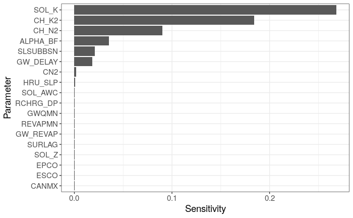

# Running the temPAWN

```r
pwn <- tempawn(sim = q_fast)

#Visualization tempPAWN for FDC
fdc_sim <- pwn$simulation$q_out%>%
  arrange(., desc(sim_max))%>%
  mutate(p = seq(0,1, length.out = nrow(.))) # This needs to consider n + 1

ggplot(fdc_sim) +
  geom_smooth(aes(x = p, y = sim_min), method = loess) +
  geom_smooth(aes(x = p, y = sim_max), method = loess) +
  labs(y = "FDC") +
  theme_bw() +
  theme(axis.title.x = element_blank(),
        axis.text.x = element_blank())

# Visualization of FDC parameters
fdc_sens<-fdc_sim%>%
  left_join(., pwn$sensitivity$q_out)%>%
  select(-date, -sim_min, -sim_max)%>%
  gather(., key = "Parameter", value = "val", -p)


ggplot(fdc_sens) +
  geom_smooth(aes(x = p, y = val, col = Parameter), method = loess) +
  # geom_line(aes(x = p, y = val, col = par)) +
  theme(legend.position = "bottom") +
  labs(x = "Exceedance probability p", y = "Sensitivity") +
  theme_bw()

#Group by months

pwn_mon <- pwn$sensitivity$q_out%>%
  mutate(month = format(date, "%m"))%>%
  group_by(month)%>%
  #group_by(month = floor_date(date, "month"))%>%
  summarize_all(., ~mean(.))%>%
  pivot_longer(., cols = colnames(pwn_mon[3:20]), names_to ="parameter") # Create a long table

#Plot a lon
ggplot(pwn_mon,aes(month,parameter,fill=value))+geom_tile()+scale_fill_gradient(low="white", high="tomato")+theme(axis.ticks = element_blank(),
        panel.background = element_blank(),
        plot.title = element_text(size = 12, colour = "gray50"))
```

[output not shown]